# Incarceration Rates of Blacks vs. Whites

Asad Jaffery

2022-11-01

## Abstract

After examining the incarceration of Americans throughout the country, it becomes clear that there is a disproportionate amount of black people that are being arrested. Although this issue is not to same extent throughout the entire country, the states that are contributing to this issue deserved to be examined. The goal of this report is to understand where the inequalities are happening the most in order to take action against them.

## Introduction

This data set examines incarceration throughout the U.S. The people who directly interact with this data set are those who have been in prison over the years. Their race and gender is collected and examined. Those who are not directly effected by this data set are those who are living in the U.S but not incarcerated, as they are still part of the data set, but are not examined to the extent to which those that are incarcerated (used for population purposes). The goal of examining this data set is to understand the disproportions of race throughout the prison system. The end goal is to understand these inequities in hopes to dismantle them. Some of the ideas that I wish to understand are: How is the amount of black people incarcerated compare to the amount of white people incarcerated on the state level, as well as how the ratio of black to white incarcerations compare throughout the United States?

## Data Summary

This data examines 1876 counties in the United States, and includes information that ranges from the year it was collected, and demographic of the population incarcerated, as well the total population. From this data, I was able to examine the county with the most black incarcerated individuals. This county happened to be the Los Angeles County in 1993. Then, I examined the Los Angeles County in order to find the ratio of black incarcerations to white incarcerations in 2018. This ratio ended up being 1.9480419. This number speaks for itself, and proves that there is some kind of systemic issue with the amount of black people being incarcerated. Lastly, I examined the average amount of white people who were incarcerated in every county and year that data was retrieved. This number is 90.6666038. The average amount of black people incarcerated in every county and year is 81.1755638.

## Growth of the U.S Prision Population

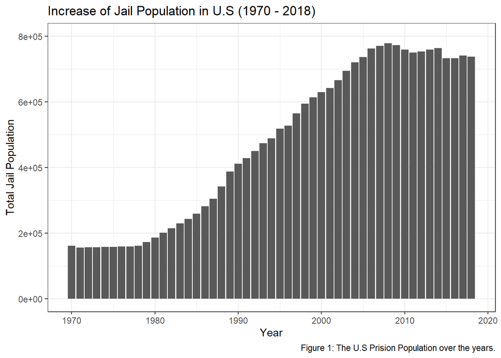

```r
plot_jail_pop_for_us()
```

## Growth of Prision Population by State

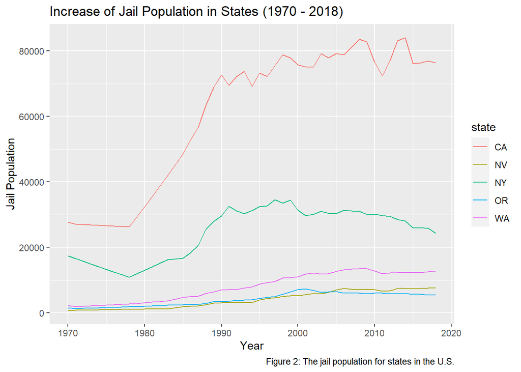

```r
plot_jail_pop_by_states(c("WA", "CA", "OR", "NV", "NY"))
```

Figure 2 shows the jail population of Washington, California, Oregon, Nevada, and New York. Holistically, the amount of people in jail has increased over the years. Although there are some fluctuations, the general trend is the same for each state that is examined. The reason that I chose these states is because I wanted to create a chart that took data from states with both, relatively large and small populations.

## Black Population in Prision vs. White Population in Prision

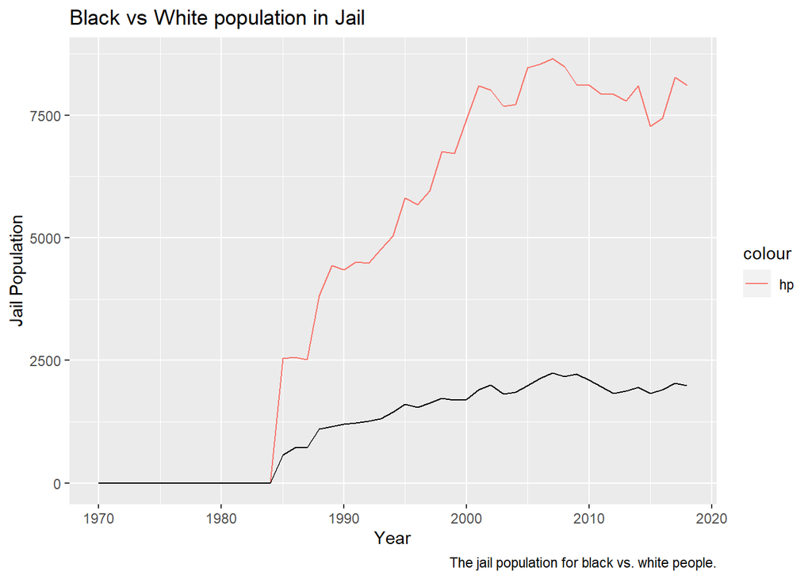

```r
plot_black_vs_white_jail_pop("WA")
```

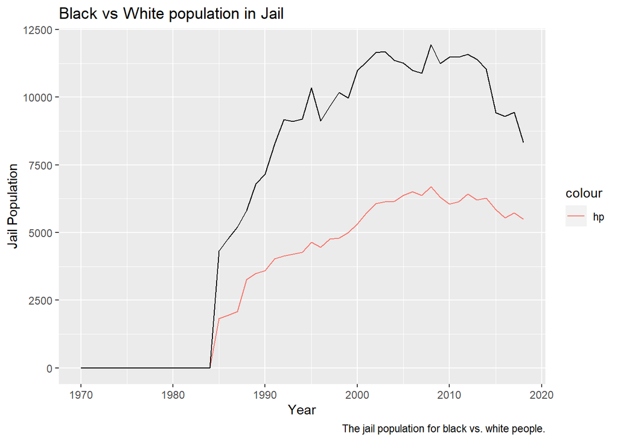

```r
plot_black_vs_white_jail_pop("IL")
```

## Black to White Ratio by State

```r
get_black_to_white_ratio()
```

[output not shown]

[figure not shown]

```r
plot_black_to_white_ratio()
```